# Text Mining With R

```r
library(data.table)
library(tidytext)
library(textdata)
library(syuzhet)
library(stringr)
library(janeaustenr)
library(gutenbergr)
library(grid)
library(gtable)
library(ggplot2)
library(RtextminerPkg)
library(RplotterPkg)
```

Author: Rick Dean

Article date: 2021-01-07

Abstract

The following notes/R scripts were inspired from Chapter 2 of [Text Mining With R](https://www.tidytextmining.com/index.html) by Julia Silge and David Robinson

Note: Functions from the `data.table` and `RtextminerPkg` packages are used in performing many of the following data set operations.

# Sentiment Analysis with Tidy Data

## The sentiments datasets

### Look at the “afinn” dictionary

```r
afinn_dt <- data.table::setDT(textdata::lexicon_afinn())
str(afinn_dt)
## Classes 'data.table' and 'data.frame':   2477 obs. of  2 variables:
##  $ word : chr  "abandon" "abandoned" "abandons" "abducted" ...
##  $ value: num  -2 -2 -2 -2 -2 -2 -3 -3 -3 -3 ...
##  - attr(*, "spec")=
##   .. cols(
##   ..   word = col_character(),
##   ..   value = col_double()
##   .. )
##  - attr(*, ".internal.selfref")=<externalptr>
```

### Look at the “bing” dictionary

```r
bing_dt <- data.table::setDT(tidytext::sentiments)
str(bing_dt)
## Classes 'data.table' and 'data.frame':   6786 obs. of  2 variables:
##  $ word     : chr  "2-faces" "abnormal" "abolish" "abominable" ...
##  $ sentiment: chr  "negative" "negative" "negative" "negative" ...
##  - attr(*, ".internal.selfref")=<externalptr>
```

### Look at the “nrc” dictionary

```r
nrc_dt <- data.table::setDT(syuzhet::get_sentiment_dictionary("nrc", language = "english"))
str(nrc_dt)
## Classes 'data.table' and 'data.frame':   13901 obs. of  4 variables:
##  $ lang     : chr  "english" "english" "english" "english" ...
##  $ word     : chr  "abba" "ability" "abovementioned" "absolute" ...
##  $ sentiment: chr  "positive" "positive" "positive" "positive" ...
##  $ value    : num  1 1 1 1 1 1 1 1 1 1 ...
##  - attr(*, ".internal.selfref")=<externalptr>
```

## Sentiment analysis with inner join

### Sentiment analysis in the Jane Austen book `Emma`

1. Get the Austen books:

```r
jane_austen_books_dt <- data.table::setDT(janeaustenr::austen_books())
str(jane_austen_books_dt)
## Classes 'data.table' and 'data.frame':   73422 obs. of  2 variables:
##  $ text: chr  "SENSE AND SENSIBILITY" "" "by Jane Austen" "" ...
##  $ book: Factor w/ 6 levels "Sense & Sensibility",..: 1 1 1 1 1 1 1 1 1 1 ...
##  - attr(*, ".internal.selfref")=<externalptr>
```

2. Create a *chapter* column from *jane_austen_books_dt*:

```r
jane_austen_books_dt[, `:=`(linenumber = .I, chapter = cumsum(str_detect(text, regex("^chapter [\\divxlc]", ignore_case = TRUE))))]
str(jane_austen_books_dt)
## Classes 'data.table' and 'data.frame':   73422 obs. of  4 variables:
##  $ text      : chr  "SENSE AND SENSIBILITY" "" "by Jane Austen" "" ...
##  $ book      : Factor w/ 6 levels "Sense & Sensibility",..: 1 1 1 1 1 1 1 1 1 1 ...
##  $ linenumber: int  1 2 3 4 5 6 7 8 9 10 ...
##  $ chapter   : int  0 0 0 0 0 0 0 0 0 1 ...
##  - attr(*, ".internal.selfref")=<externalptr>
```

3. Using `RtextminerPkg::tokenize_text()` to get the words of Jane Austen books:

```r
austen_words_lst <- RtextminerPkg::tokenize_text(
  x = jane_austen_books_dt,
  input_col = "text",
  output_col = "word",
  #stopwords = stopwords::stopwords(language = "en"),
  stopwords = tidytext::stop_words$word,
  strip_punct = TRUE
)
austen_words_lst$tokens_dt[1:10]
##                    book linenumber chapter        word
##  1: Sense & Sensibility          1       0       sense
##  2: Sense & Sensibility          1       0 sensibility
##  3: Sense & Sensibility          3       0        jane
##  4: Sense & Sensibility          3       0      austen
##  5: Sense & Sensibility          5       0        1811
##  6: Sense & Sensibility         10       1     chapter
##  7: Sense & Sensibility         10       1           1
##  8: Sense & Sensibility         13       1      family
##  9: Sense & Sensibility         13       1    dashwood
## 10: Sense & Sensibility         13       1     settled
```

4. Select the `Emma` words:

```r
emma_words_dt <- austen_words_lst$tokens_dt[book == "Emma"]
emma_words_dt[1:10]
##     book linenumber chapter      word
##  1: Emma      41004     159      emma
##  2: Emma      41006     159      jane
##  3: Emma      41006     159    austen
##  4: Emma      41011     159    volume
##  5: Emma      41015     160   chapter
##  6: Emma      41018     160      emma
##  7: Emma      41018     160 woodhouse
##  8: Emma      41018     160  handsome
##  9: Emma      41018     160    clever
## 10: Emma      41018     160      rich
```

5. Get the “joy” words from the “nrc” dictionary:

```r
joy_words_dt <- nrc_dt[sentiment == "joy"]
joy_words_dt[1:10]
##        lang          word sentiment value
##  1: english    absolution       joy     1
##  2: english     abundance       joy     1
##  3: english      abundant       joy     1
##  4: english      accolade       joy     1
##  5: english accompaniment       joy     1
##  6: english    accomplish       joy     1
##  7: english  accomplished       joy     1
##  8: english       achieve       joy     1
##  9: english   achievement       joy     1
## 10: english       acrobat       joy     1
```

6. Inner join the “joy” words with the words in `Emma`:

```r
emma_joy_dt <- RtextminerPkg::join_words(emma_words_dt, joy_words_dt)
emma_joy_dt[, .(book, sentiment, value)][1:10]
##     book sentiment value
##  1: Emma       joy     1
##  2: Emma       joy     1
##  3: Emma       joy     1
##  4: Emma       joy     1
##  5: Emma       joy     1
##  6: Emma       joy     1
##  7: Emma       joy     1
##  8: Emma       joy     1
##  9: Emma       joy     1
## 10: Emma       joy     1
```

7. Get the frequency of words that are “joy”:

```r
emma_joy_n_dt <- emma_joy_dt[, .(.N), by = word][order(-N)]
emma_joy_n_dt[1:10]
##          word   N
##  1:    friend 166
##  2:      hope 143
##  3:     happy 125
##  4:      love 117
##  5:      deal  92
##  6:     found  92
##  7: happiness  76
##  8:    pretty  68
##  9:   comfort  65
## 10:   spirits  64
```

## Sentiment changes

1. Inner join all of the Jane Austen books of words with the `Bing` lexicon

```r
austen_bing_dt <- RtextminerPkg::join_words(austen_words_lst$tokens_dt, bing_dt)
austen_bing_dt[1:10]
##                  book linenumber chapter       word sentiment
##  1: Pride & Prejudice      13811      58 abominable  negative
##  2: Pride & Prejudice      14586      61 abominable  negative
##  3: Pride & Prejudice      15428      66 abominable  negative
##  4: Pride & Prejudice      15439      66 abominable  negative
##  5: Pride & Prejudice      17529      76 abominable  negative
##  6: Pride & Prejudice      19165      84 abominable  negative
##  7:    Mansfield Park      28778     120 abominable  negative
##  8:    Mansfield Park      30241     126 abominable  negative
##  9:    Mansfield Park      35340     141 abominable  negative
## 10:              Emma      45150     174 abominable  negative
```

2. Add an *index* column that reflects each word’s location by dividing the *linenumber* variable by integer of 80. The *index* keeps track of which 80-line section of the text we are counting up negative and positive sentiments in:

```r
austen_bing_dt[, index := (linenumber %/% 80)]
austen_bing_dt[,.(book, word, sentiment, index)][1:10]
##                  book       word sentiment index
##  1: Pride & Prejudice abominable  negative   172
##  2: Pride & Prejudice abominable  negative   182
##  3: Pride & Prejudice abominable  negative   192
##  4: Pride & Prejudice abominable  negative   192
##  5: Pride & Prejudice abominable  negative   219
##  6: Pride & Prejudice abominable  negative   239
##  7:    Mansfield Park abominable  negative   359
##  8:    Mansfield Park abominable  negative   378
##  9:    Mansfield Park abominable  negative   441
## 10:              Emma abominable  negative   564
```

3. Group by *book*, *index*, and *sentiment* and get the counts:

```r
austen_sentiment_dt <- austen_bing_dt[, .(.N), by = .(book, index, sentiment)]
austen_sentiment_dt[1:10][order(-N)]
##                  book index sentiment  N
##  1: Pride & Prejudice   182  negative 40
##  2:              Emma   564  negative 39
##  3: Pride & Prejudice   192  negative 33
##  4:              Emma   652  negative 31
##  5: Pride & Prejudice   172  negative 29
##  6: Pride & Prejudice   239  negative 29
##  7:    Mansfield Park   359  negative 27
##  8:    Mansfield Park   441  negative 20
##  9:    Mansfield Park   378  negative 19
## 10: Pride & Prejudice   219  negative 16
```

4. To plot the above results, reshape *austen_sentiment_dt* to a “wide” format where we collect all the *N* values across the same row based on columns of *sentiment*:

```r
austen_sentiment_wide_dt <- data.table::dcast(austen_sentiment_dt, book + index ~ sentiment, value.var = "N")
str(austen_sentiment_wide_dt)
## Classes 'data.table' and 'data.frame':   923 obs. of  4 variables:
##  $ book    : Factor w/ 6 levels "Sense & Sensibility",..: 1 1 1 1 1 1 1 1 1 1 ...
##  $ index   : num  0 1 2 3 4 5 6 7 8 9 ...
##  $ negative: int  16 19 12 15 16 16 24 22 30 14 ...
##  $ positive: int  26 44 23 22 29 39 37 39 35 18 ...
##  - attr(*, ".internal.selfref")=<externalptr>
##  - attr(*, "sorted")= chr [1:2] "book" "index"
```

5. Add a *sentiment_val* column to *austen_sentiment_wide_dt* by taking the difference in the frequency values (i.e. *positive* - *negative*):

```r
austen_sentiment_wide_dt[, sentiment_val := (positive - negative)]
austen_sentiment_wide_dt[1:10]
##                    book index negative positive sentiment_val
##  1: Sense & Sensibility     0       16       26            10
##  2: Sense & Sensibility     1       19       44            25
##  3: Sense & Sensibility     2       12       23            11
##  4: Sense & Sensibility     3       15       22             7
##  5: Sense & Sensibility     4       16       29            13
##  6: Sense & Sensibility     5       16       39            23
##  7: Sense & Sensibility     6       24       37            13
##  8: Sense & Sensibility     7       22       39            17
##  9: Sense & Sensibility     8       30       35             5
## 10: Sense & Sensibility     9       14       18             4
```

6. Plot the *sentiment_val* across the *index* for each of the books:

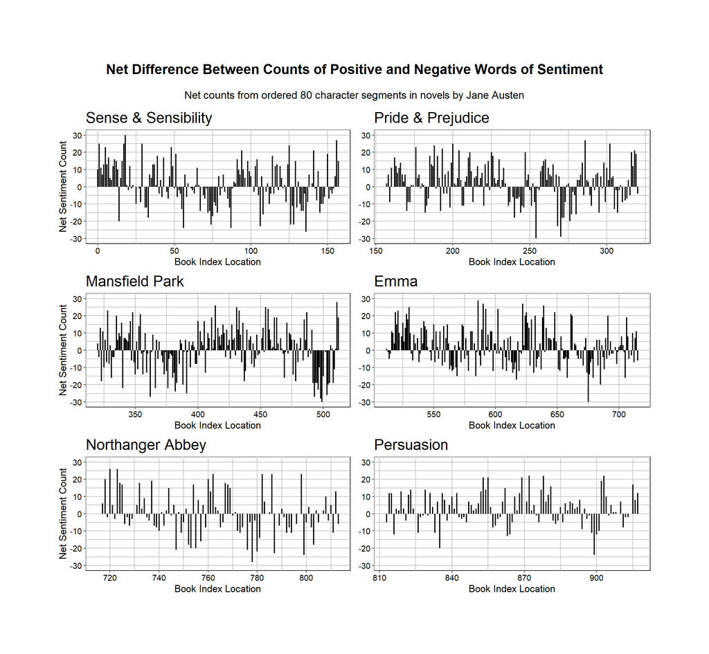

```r
RplotterPkg::multi_stick_plot(
  df = austen_sentiment_wide_dt,
  factor_var = "book",
  factor_x = "index",
  aes_y = "sentiment_val",
  title = "Net Difference Between Counts of Positive and Negative Words of Sentiment",
  subtitle = "Net counts from ordered 80 character segments in novels by Jane Austen",
  x_title = "Book Index Location",
  y_titles = rep("Net Sentiment Count",6),
  y_limits = c(-30,30),
  y_major_breaks = seq(-30,30,10),
  rot_y_tic_label = T,
  col_width = 5.5,
  row_height = 3
)
```

> The plots show how each novel changes toward more positive or negative sentiment over the trajectory of the story.

## Comparing sentiment lexicons

### Comparing afinn, bing, and nrc lexicons for sentiment classification

Note: See the R script for this topic in the current directory at `compare_lexicons.R`

### Comparing NRC with Bing for the ratio of negative to positive

1. Get the ratio of negetive over positive words in the NRC lexicon:

```r
nrc_dt <- data.table::setDT(syuzhet::get_sentiment_dictionary("nrc", language = "english"))
nrc_neg_pos_dt <- nrc_dt[sentiment %in% c("positive", "negative"), .N ,by = sentiment]
str(nrc_neg_pos_dt)
## Classes 'data.table' and 'data.frame':   2 obs. of  2 variables:
##  $ sentiment: chr  "positive" "negative"
##  $ N        : int  2312 3324
##  - attr(*, ".internal.selfref")=<externalptr>
```

2. Take the ratio of negative to positive counts:

```r
nrc_neg_pos_ratio <- nrc_neg_pos_dt$N[[2]]/nrc_neg_pos_dt$N[[1]]
nrc_neg_pos_ratio
## [1] 1.437716
```

3. Get the ratio of negative over positive words in the Bing lexicon:

```r
bing_dt <- data.table::setDT(tidytext::sentiments)
bing_neg_pos_dt <- bing_dt[, .N, by = sentiment]
str(bing_neg_pos_dt)
## Classes 'data.table' and 'data.frame':   2 obs. of  2 variables:
##  $ sentiment: chr  "negative" "positive"
##  $ N        : int  4781 2005
##  - attr(*, ".internal.selfref")=<externalptr>
```

4. Take the ratio of negative to positive counts:

```r
bing_neg_pos_ratio <- bing_neg_pos_dt$N[[1]]/bing_neg_pos_dt$N[[2]]
bing_neg_pos_ratio
## [1] 2.384539
```

Note: There appears to be higher negative words in both lexicons and with a higher ratio in Bing.

### Most common positive and negative words in a text

1. Find the words across all of Austen’s novelsd:

```r
jane_austen_books_dt <- data.table::setDT(janeaustenr::austen_books())
austen_words_lst <- RtextminerPkg::tokenize_text(
  x = jane_austen_books_dt,
  input_col = "text",
  output_col = "word"
)
austen_words_dt <- austen_words_lst$tokens_dt
str(austen_words_dt)
## Classes 'data.table' and 'data.frame':   864758 obs. of  2 variables:
##  $ book: Factor w/ 6 levels "Sense & Sensibility",..: 1 1 1 1 1 1 1 1 1 1 ...
##  $ word: chr  "sense" "and" "sensibility" "by" ...
##  - attr(*, ".internal.selfref")=<externalptr>
```

2. Do an inner join of all the Austen words with the Bing lexicon:

```r
bing_dt <- data.table::setDT(tidytext::sentiments)
austen_bing_dt <- RtextminerPkg::join_words(austen_words_dt, bing_dt)
str(austen_bing_dt)
## Classes 'data.table' and 'data.frame':   52287 obs. of  3 variables:
##  $ book     : Factor w/ 6 levels "Sense & Sensibility",..: 2 2 2 2 2 2 3 3 3 4 ...
##  $ word     : chr  "abominable" "abominable" "abominable" "abominable" ...
##  $ sentiment: chr  "negative" "negative" "negative" "negative" ...
##  - attr(*, "sorted")= chr "word"
##  - attr(*, ".internal.selfref")=<externalptr>
```

3. Get the top word counts that are common to both the Austen and Bing lexicon words:

```r
austen_bing_counts_dt <- austen_bing_dt[, .N, by = .(word, sentiment)][order(-N)]
austen_bing_counts_dt[1:10]
##         word sentiment    N
##  1:     miss  negative 1855
##  2:     well  positive 1523
##  3:     good  positive 1380
##  4:    great  positive  981
##  5:     like  positive  725
##  6:   better  positive  639
##  7:   enough  positive  613
##  8:    happy  positive  534
##  9:     love  positive  495
## 10: pleasure  positive  462
```

4. Plot a bar chart of the top 10 positive and negative words:

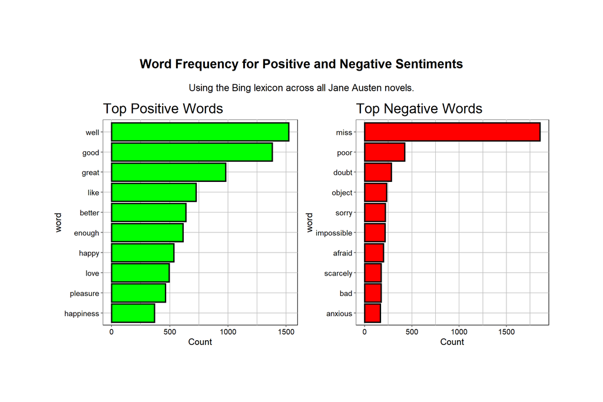

```r
austen_bing_positive_dt <- austen_bing_counts_dt[sentiment == "positive"][1:10]
austen_bing_negative_dt <- austen_bing_counts_dt[sentiment == "negative"][1:10]
positive_wrd_plot <- RplotterPkg::create_bar_plot(
  df = austen_bing_positive_dt,
  aes_x = "word",
  aes_y = "N",
  title = "Top Positive Words",
  do_coord_flip = T,
  rot_y_tic_label = T,
  bar_fill = "green",
  order_bars = "asc"
)
negative_wrd_plot <- RplotterPkg::create_bar_plot(
  df = austen_bing_negative_dt,
  aes_x = "word",
  aes_y = "N",
  title = "Top Negative Words",
  do_coord_flip = T,
  rot_y_tic_label = T,
  bar_fill = "red",
  order_bars = "asc"
)
layout <- list(
  plots = list(positive_wrd_plot, negative_wrd_plot),
  rows = c(1,1),
  cols = c(1,2)
)
RplotterPkg::multi_panel_grid(
  layout = layout,
  col_widths = c(5,5),
  row_heights = c(5),
  title = "Word Frequency for Positive and Negative Sentiments",
  subtitle = "Using the Bing lexicon across all Jane Austen novels."
)
```

## Using a regex pattern for tokenization

### Number of chapters in each book

1. Get Jane Auten books:

```r
jane_austen_books_dt <- data.table::setDT(janeaustenr::austen_books())
```

2. Tokenize the text using regex to locate rows with a chapter pattern:

```r
jane_austen_books_dt <- data.table::setDT(janeaustenr::austen_books())
jane_austen_chapters_dt <- RtextminerPkg::tokenize_text(
  x = jane_austen_books_dt,
  type = "regex",
  input_col = "text",
  output_col = "chapter",
  regex_pattern = "Chapter|CHAPTER [\\dIVXLC]",
  regex_return = "logical"
)
```

3. Sum the number of chapters for each book:

```r
jane_auten_chapters_totals_dt <- jane_austen_chapters_dt$tokens_dt[, .(chapters = sum(chapter)), by = book]
print(jane_auten_chapters_totals_dt)
##                   book chapters
## 1: Sense & Sensibility       50
## 2:   Pride & Prejudice       61
## 3:      Mansfield Park       49
## 4:                Emma       57
## 5:    Northanger Abbey       33
## 6:          Persuasion       24
```

### Number of words in each chapter

1. Get the Austen books and add a *chapter* variable:

```r
ja_books_dt <- data.table::setDT(janeaustenr::austen_books())
ja_books_dt[, chapter := cumsum(str_detect(text, regex("^chapter [\\divxlc]", ignore_case = TRUE))), by = book]
str(ja_books_dt)
## Classes 'data.table' and 'data.frame':   73422 obs. of  3 variables:
##  $ text   : chr  "SENSE AND SENSIBILITY" "" "by Jane Austen" "" ...
##  $ book   : Factor w/ 6 levels "Sense & Sensibility",..: 1 1 1 1 1 1 1 1 1 1 ...
##  $ chapter: int  0 0 0 0 0 0 0 0 0 1 ...
##  - attr(*, ".internal.selfref")=<externalptr>
```

2. Remove the “0” chapter:

```r
ja_books_dt <- ja_books_dt[chapter != 0]
str(ja_books_dt)
## Classes 'data.table' and 'data.frame':   73347 obs. of  3 variables:
##  $ text   : chr  "CHAPTER 1" "" "" "The family of Dashwood had long been settled in Sussex.  Their estate" ...
##  $ book   : Factor w/ 6 levels "Sense & Sensibility",..: 1 1 1 1 1 1 1 1 1 1 ...
##  $ chapter: int  1 1 1 1 1 1 1 1 1 1 ...
##  - attr(*, ".internal.selfref")=<externalptr>
```

3. Tokenize `ja_books_dt` by word:

```r
ja_words_lst <- RtextminerPkg::tokenize_text(
  x = ja_books_dt,
  input_col = "text",
  output_col = "word"
)
ja_words_dt <- ja_words_lst$tokens_dt
str(ja_words_dt)
## Classes 'data.table' and 'data.frame':   864557 obs. of  3 variables:
##  $ book   : Factor w/ 6 levels "Sense & Sensibility",..: 1 1 1 1 1 1 1 1 1 1 ...
##  $ chapter: int  1 1 1 1 1 1 1 1 1 1 ...
##  $ word   : chr  "chapter" "1" "the" "family" ...
##  - attr(*, ".internal.selfref")=<externalptr>
```

4. Get the number of words in each chapter:

```r
ja_chapter_wrds_n_dt <- ja_words_dt[, .(words = .N), by = .(book, chapter)]
str(ja_chapter_wrds_n_dt)
## Classes 'data.table' and 'data.frame':   269 obs. of  3 variables:
##  $ book   : Factor w/ 6 levels "Sense & Sensibility",..: 1 1 1 1 1 1 1 1 1 1 ...
##  $ chapter: int  1 2 3 4 5 6 7 8 9 10 ...
##  $ words  : int  1846 2357 1795 2271 1191 1515 1434 1466 2199 2430 ...
##  - attr(*, ".internal.selfref")=<externalptr>
```

### Get the number of negative Bing words in each chapter

1. Get the negative words from Bing lexicon:

```r
bing_dt <- data.table::setDT(tidytext::sentiments)
bing_neg_dt <- bing_dt[sentiment == "negative"]
str(bing_neg_dt)
## Classes 'data.table' and 'data.frame':   4781 obs. of  2 variables:
##  $ word     : chr  "2-faces" "abnormal" "abolish" "abominable" ...
##  $ sentiment: chr  "negative" "negative" "negative" "negative" ...
##  - attr(*, ".internal.selfref")=<externalptr>
```

2. Inner join the Austen words with the negative Bing words:

```r
ja_neg_dt <- RtextminerPkg::join_words(ja_words_dt, bing_neg_dt)
str(ja_neg_dt)
## Classes 'data.table' and 'data.frame':   21676 obs. of  4 variables:
##  $ book     : Factor w/ 6 levels "Sense & Sensibility",..: 2 2 2 2 2 2 3 3 3 4 ...
##  $ chapter  : int  8 11 16 16 26 34 9 15 30 15 ...
##  $ word     : chr  "abominable" "abominable" "abominable" "abominable" ...
##  $ sentiment: chr  "negative" "negative" "negative" "negative" ...
##  - attr(*, "sorted")= chr "word"
##  - attr(*, ".internal.selfref")=<externalptr>
```

3. Find the number of negative words in each chapter:

```r
ja_neg_chap_n_dt <- ja_neg_dt[, .(neg_words = .N), by = .(book, chapter)]
str(ja_neg_chap_n_dt)
## Classes 'data.table' and 'data.frame':   269 obs. of  3 variables:
##  $ book     : Factor w/ 6 levels "Sense & Sensibility",..: 2 2 2 2 2 3 3 3 4 4 ...
##  $ chapter  : int  8 11 16 26 34 9 15 30 15 39 ...
##  $ neg_words: int  68 76 92 72 111 124 130 51 151 65 ...
##  - attr(*, ".internal.selfref")=<externalptr>
```

```r
data.table::setkey(ja_chapter_wrds_n_dt, book, chapter)
data.table::setkey(ja_neg_chap_n_dt, book, chapter)
ja_neg_join_dt <- ja_chapter_wrds_n_dt[ja_neg_chap_n_dt, nomatch = 0]
str(ja_neg_join_dt)
## Classes 'data.table' and 'data.frame':   269 obs. of  4 variables:
##  $ book     : Factor w/ 6 levels "Sense & Sensibility",..: 1 1 1 1 1 1 1 1 1 1 ...
##  $ chapter  : int  1 2 3 4 5 6 7 8 9 10 ...
##  $ words    : int  1846 2357 1795 2271 1191 1515 1434 1466 2199 2430 ...
##  $ neg_words: int  35 31 42 64 20 20 30 56 43 68 ...
##  - attr(*, "sorted")= chr [1:2] "book" "chapter"
##  - attr(*, ".internal.selfref")=<externalptr>
```

5. Add a *ratio* variable dividing *neg_words* by *words*:

```r
ja_neg_join_dt[, ratio := neg_words/words][order(-ratio)][1:10]
##                    book chapter words neg_words      ratio
##  1:   Pride & Prejudice      34  2460       111 0.04512195
##  2:    Northanger Abbey      21  3432       149 0.04341492
##  3:   Pride & Prejudice      41  2688       113 0.04203869
##  4:   Pride & Prejudice      36  2305        96 0.04164859
##  5:      Mansfield Park      46  4323       173 0.04001851
##  6: Sense & Sensibility      43  4046       161 0.03979239
##  7:      Mansfield Park      45  3327       132 0.03967538
##  8:      Mansfield Park      48  5097       199 0.03904257
##  9:   Pride & Prejudice      46  3568       139 0.03895740
## 10:      Mansfield Park      44  3738       145 0.03879080
```

6. Show Emma, chapter 15:

```r
ja_neg_join_dt[book == "Emma" & chapter == 15]
##    book chapter words neg_words      ratio
## 1: Emma      15  4020       151 0.03756219
```